# First Steps with Item Response Theory

Item time!

Dr. Ottavia M. Epifania

ottavia.epifania@unitn.it

# Item fit

The fit of each item to the model can be evaluated:

$S - X^2$ (Orland & Thissen, 2000): Statistics based on the $\chi^2$. If significant, the item does not fit to the model (not suggested)

*Root Mean Squared Deviation* (RMSD): Difference between what expected under the model and real data (the lower the better).

> $< .15$: acceptable fit of the item to the model

> $< .10$: optimal fit of the item to the model
- Rasch model only $\rightarrow$ Infit and outfit statistics

## Evaluating item fit I

- Look at the data
- Fitting & choosing a model
- Fit of the model

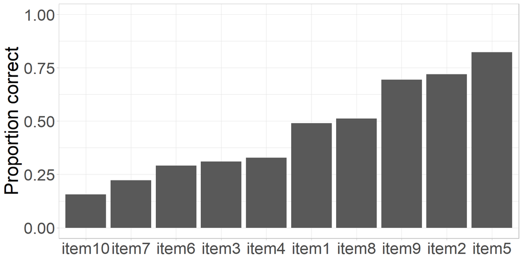

```r
data = read.csv("data/itemClass.csv", header = T, sep = ",")
prop_item = data.frame(item = names(colMeans(data[, -c(1:2)])),
           proportion = colMeans(data[, -c(1:2)]))

ggplot(prop_item,
       aes(x = reorder(item, proportion),
           y = proportion), color = item) + geom_bar(stat = "identity") + theme_light() +
  ylab("Proportion correct") + ylim(0, 1) +
  theme(legend.position = "none",
        axis.title = element_text(size = 26),
        axis.title.x = element_blank(),
        axis.text = element_text(size = 22))
```

[output not shown]

```r
m1pl = tam.mml(data[, grep("item", colnames(data))], verbose = F)
m2pl = tam.mml.2pl(data[, grep("item", colnames(data))], irtmodel = "2PL", verbose = F)
m3pl = tam.mml.3pl(data[, grep("item", colnames(data))], est.guess = grep("item", colnames(data)), verbose = F)
IRT.compareModels(m1pl, m2pl, m3pl)
```

```r
fit_m1pl = tam.modelfit(m1pl, progress = F)
fit_m1pl$statlist
```

```
  X100.MADCOV       SRMR      SRMSR     MADaQ3 pmaxX2
1   0.4318818 0.02178404 0.02800907 0.02874571      1
```

## Evaluating item fit II

- Item fit
- $\chi^2$
- RMSD

```r
item_fit_1pl = IRT.itemfit(m1pl)
str(item_fit_1pl)
```

```
List of 11
 $ MD             :'data.frame':    10 obs. of  2 variables:
  ..$ item  : chr [1:10] "item1" "item2" "item3" "item4" ...
  ..$ Group1: num [1:10] -2.21e-06 1.09e-06 -4.23e-06 -4.09e-06 1.97e-06 ...
 $ RMSD           :'data.frame':    10 obs. of  2 variables:
  ..$ item  : chr [1:10] "item1" "item2" "item3" "item4" ...
  ..$ Group1: num [1:10] 0.01389 0.00794 0.01089 0.00595 0.01088 ...
 $ RMSD_bc        :'data.frame':    10 obs. of  2 variables:
  ..$ item  : chr [1:10] "item1" "item2" "item3" "item4" ...
  ..$ Group1: num [1:10] -0.00371 -0.01037 -0.00785 -0.01225 -0.00296 ...
 $ MAD            :'data.frame':    10 obs. of  2 variables:
  ..$ item  : chr [1:10] "item1" "item2" "item3" "item4" ...
  ..$ Group1: num [1:10] 0.01235 0.00612 0.00945 0.00538 0.00908 ...
 $ chisquare_stat :'data.frame':    10 obs. of  2 variables:
  ..$ item  : chr [1:10] "item1" "item2" "item3" "item4" ...
  ..$ Group1: num [1:10] 1.234 0.594 0.667 0.312 1.135 ...
 $ call           : language CDM::IRT.RMSD(object = object)
 $ G              : num 1
 $ RMSD_summary   :'data.frame':    1 obs. of  5 variables:
  ..$ Parm: chr "Group1"
....
```

```r
item_fit_1pl$chisquare_stat
```

```
     item    Group1
1   item1 1.2342630
2   item2 0.5938130
3   item3 0.6668817
4   item4 0.3117211
5   item5 1.1353671
6   item6 0.3983689
7   item7 2.2867280
8   item8 0.4899905
9   item9 1.2476006
10 item10 0.3184401
```

```r
item_fit_1pl$RMSD_summary
```

```
    Parm          M          SD         Min        Max
1 Group1 0.01071287 0.004171214 0.005948698 0.01983321
```

```r
item_fit_1pl$RMSD
```

```
     item      Group1
1   item1 0.013892105
2   item2 0.007935321
3   item3 0.010894367
4   item4 0.005948698
5   item5 0.010882772
6   item6 0.008170491
7   item7 0.019833211
8   item8 0.009002479
9   item9 0.013681206
10 item10 0.006888076
```

# Differential Item Functioning

## An example

The mass of Iodine 131 decreases by 1/2 every 8 days because of radioactive decay.

In a laboratory, there are 2grams of Iodine 131. How many grams there would be after 16 days?

**Correct response**

0.5grams

## Item Charcteristic Curve (ICC)

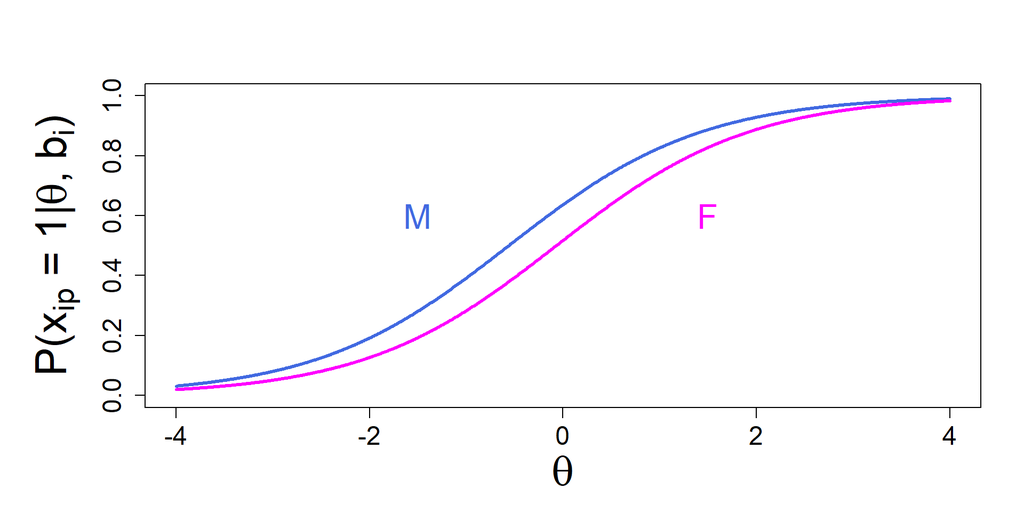

The same item presented to two different groups paired for their level of latent trait… does not have the same probability of being endorsed!

The subjects are paired according to their level of the latent trait. **Are there any differences in the performance to the item**?

Theoretically: Different subjects but with the same level of the latent trait (i.e., **paired**) should have similar performances on the item

If this expectation is not met $\rightarrow$ **Differential Item Functioning** (**DIF**)

## Reference vs. focal group

The comparison to investigate items with DIF is between two groups:

- **Reference group**: It is the “baseline” group. For instance, if the test/questionnaire has been validated in a second language, the reference group is the original group
- **Focal group**: It is the focus of the DIF investigation, where we suspect the items of the test might be working differently

## Uniform DIF

The item “favors” one of the two groups (either the focal or the reference one) *constantly*

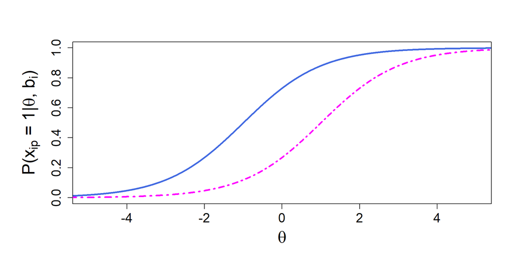

## Non-uniform DIF

The item favors one of the group $\rightarrow$ it is not constant along the latent trait

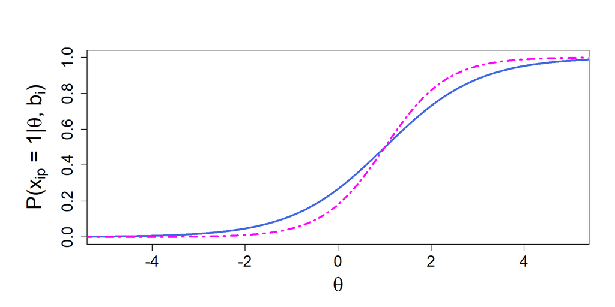

## DIF Investigation

IRT-based methods: Subjects are paired according to the estimates of their *latent trait level* $\theta$

Score-based methods: Subjects are paired to the the *observed score*

Uniform DIF

1PL

2PL

3PL

Non-uniform DIF

2PL

3PL

## Likelihood Ratio Test

### Thissen, Steinber, & Wainer (1998)

Two IRT models:

1. A “no DIF” model $\rightarrow$ Parameters are constrained to be equal in the two groups
2. A “DIF” model $\rightarrow$ Parameters are left free to vary between the two groups

It is like the LRT on a linear model where the group variable (Focal Vs. Reference) is used as a predictor or not

## Lord

### Lord (1980)

The item parameters are estimated in both the reference and the focal groups

If there is a significant difference in the item estimates between groups $\rightarrow$ DIF

Beyond significance: Lord’s $\Delta$:

> $< 1.00$: Negligible DIF

> $1.00 < d < 1.5$: Moderate DIF

> $> 1.5$: High DIF

## Raju’s Area

### Raju (1988)

It considers the DIF as the area between the ICCs of the items

If the area between the ICCs is 0, then the item presents no DIF

It is based on a $Z$ statistic under the null hypothesis that the area between the ICCs of the item in the two groups is 0

## A note on Lord and Raju

The parameters estimated in the focal and reference groups cannot be directly compared $\rightarrow$ The parameters in one of the groups **must** be rescaled.

The rescaling can be done according to the *equal means anchoring* method (Cook & Eignor, 1991)

This method is already applied in the [`difR`](https://cran.r-project.org/web/packages/difR/difR.pdf) package

## Equal means anchoring

### Cook & Eignor (1991)

First, a constant must be computed:

$$c = \bar{b}_R - \bar{b}_F$$

Then, it is subtracted from the estimates of the items in the **reference group**:

$$b' = b_{i}^{\text{Reference}} - c$$

## DIF – Import data

The dataset is the [`difClass.csv`](https://drive.google.com/file/d/1G7Eu5WKyqEcJHXI-dlXfJ2tVux_eMAWv/view?usp=sharing) data set

**Show data & code**

```r
data = read.csv("data/difClass.csv", header = T, sep = ",")
head(data)
```

```
  id gender item1 item2 item3 item4 item5 item6 item7 item8 item9 item10
1  1      m     0     1     0     1     1     0     0     1     1      0
2  2      m     0     1     0     0     1     0     0     0     0      0
3  3      m     0     1     1     1     1     1     0     1     1      0
4  4      m     1     0     0     1     1     0     0     0     1      0
5  5      m     1     1     0     0     1     1     1     1     0      0
6  6      m     0     0     0     0     1     0     0     0     0      0
```

- Look at the data
- Fit & Choose a model
- Model fit
- Item fit

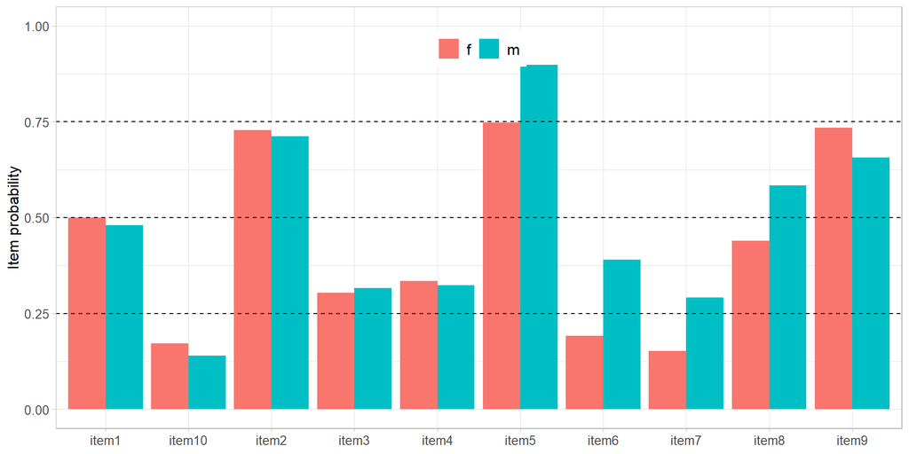

```r
long = pivot_longer(data, !1:2, names_to = "item",
             values_to = "correct")
prop_gender = long %>%
  group_by(item, gender) %>%
  summarise(prop = mean(correct), sd = sd(correct))

ggplot(prop_gender,
       aes( x = item, y= prop, fill = gender)) + geom_bar(stat = "identity", position = position_dodge()) + ylim(0,1)
```

```r
m1pl = tam.mml(data[, grep("item", colnames(data))], verbose = F)
m2pl = tam.mml.2pl(data[, grep("item", colnames(data))], irtmodel = "2PL", verbose = F)
m3pl = tam.mml.3pl(data[, grep("item", colnames(data))], est.guess = grep("item", colnames(data)),
                     verbose = F)
IRT.compareModels(m1pl, m2pl, m3pl)
```

```
$IC
  Model   loglike Deviance Npars Nobs      AIC      BIC     AIC3     AICc
1  m1pl -5599.390 11198.78    11 1000 11220.78 11274.77 11231.78 11221.05
2  m2pl -5597.621 11195.24    20 1000 11235.24 11333.40 11255.24 11236.10
3  m3pl -5597.736 11195.47    31 1000 11257.47 11409.61 11288.47 11259.52
      CAIC       GHP
1 11285.77 0.5610390
2 11353.40 0.5617621
3 11440.61 0.5628736

$LRtest
  Model1 Model2       Chi2 df         p
1   m1pl   m2pl  3.5389531  9 0.9390614
2   m1pl   m3pl  3.3079257 20 0.9999905
3   m2pl   m3pl -0.2310274 11 1.0000000

attr(,"class")
[1] "IRT.compareModels"
```

```r
fit_m1pl = tam.modelfit(m1pl, progress = F)
fit_m1pl$statlist
```

```
  X100.MADCOV       SRMR      SRMSR     MADaQ3 pmaxX2
1   0.4318818 0.02178404 0.02800907 0.02874571      1
```

```r
item_fit_1pl = IRT.itemfit(m1pl)
item_fit_1pl$RMSD_summary
```

```
    Parm          M          SD         Min        Max
1 Group1 0.01071287 0.004171214 0.005948698 0.01983321
```

```r
 fit_m1pl$Q3_summary
```

```
  type             M         SD         min        max      SGDDM     wSGDDM
1   Q3 -6.608155e-02 0.03590523 -0.14242523 0.01903314 0.06742440 0.06742440
2  aQ3  3.468830e-18 0.03590523 -0.07634368 0.08511468 0.02874571 0.02874571
```

## DIF – LRT

This is not properly the LRT but an approximation.

```r
est_theta = IRT.factor.scores(m1pl)$EAP
lrt_dif = difGenLogistic(data[, !colnames(data) %in% c("id", "gender")],
                           group = as.factor(data$gender), focal.names = "f",
                           type = "udif",
                           alpha = .001, p.adjust.method = "BH",
                           match = est_theta,
                           criterion = "LRT")
```

```
Detection of uniform Differential Item Functioning
using Logistic regression method, without item purification
and with LRT DIF statistic

Matching variable: specified matching variable

No set of anchor items was provided

Multiple comparisons made with Benjamini-Hochberg adjustement of p-values

Logistic regression DIF statistic:

       Stat.   P-value Adj. P
item1   9.5769  0.0020  0.0033 **
item2   7.8345  0.0051  0.0064 **
item3   2.8907  0.0891  0.0891 .
item4   6.6418  0.0100  0.0111 *
item5  28.1792  0.0000  0.0000 ***
item6  36.3876  0.0000  0.0000 ***
item7  18.8507  0.0000  0.0000 ***
item8   9.8524  0.0017  0.0033 **
item9  27.3310  0.0000  0.0000 ***
item10  8.9442  0.0028  0.0040 **

Signif. codes: 0 '***' 0.001 '**' 0.01 '*' 0.05 '.' 0.1 ' ' 1

Detection threshold: 10.8276 (significance level: 0.001)

Items detected as uniform DIF items:

 item5
 item6
 item7
 item9


Effect size (Nagelkerke's R^2):

Effect size code:
 'A': negligible effect
 'B': moderate effect
 'C': large effect

       R^2    ZT JG
item1  0.0092 A  A
item2  0.0086 A  A
item3  0.0030 A  A
item4  0.0069 A  A
item5  0.0368 A  B
item6  0.0394 A  B
item7  0.0231 A  A
item8  0.0098 A  A
item9  0.0293 A  A
item10 0.0130 A  A

Effect size codes:
 Zumbo & Thomas (ZT): 0 'A' 0.13 'B' 0.26 'C' 1
 Jodoin & Gierl (JG): 0 'A' 0.035 'B' 0.07 'C' 1

 Output was not captured!
```

## DIF – Raju

```r
rajDif = difRaju(data[, !colnames(data) %in% c("id")],
                  group = "gender",  focal.name = "f",
                  model = "1PL",
                  alpha = .001, p.adjust.method = "BH")
```

```
Detection of Differential Item Functioning using Raju's method
with 1PL model and without item purification

Type of Raju's Z statistic: based on unsigned area

Engine 'ltm' for item parameter estimation

Common discrimination parameter: fixed to 1

No set of anchor items was provided

Multiple comparisons made with Benjamini-Hochberg adjustement of p-values

Raju's statistic:

       Stat.   P-value Adj. P
item1  -2.7358  0.0062  0.0104 *
item2  -2.5503  0.0108  0.0154 *
item3  -1.5133  0.1302  0.1302
item4  -2.2916  0.0219  0.0244 *
item5   4.4742  0.0000  0.0000 ***
item6   5.0150  0.0000  0.0000 ***
item7   3.6098  0.0003  0.0008 ***
item8   2.4605  0.0139  0.0173 *
item9  -4.6929  0.0000  0.0000 ***
item10 -2.9145  0.0036  0.0071 **

Signif. codes: 0 '***' 0.001 '**' 0.01 '*' 0.05 '.' 0.1 ' ' 1

Detection thresholds: -3.2905 and 3.2905 (significance level: 0.001)

Items detected as DIF items:

 item5
 item6
 item7
 item9

Effect size (ETS Delta scale):

Effect size code:
 'A': negligible effect
 'B': moderate effect
 'C': large effect

       mF-mR   deltaRaju
item1  -0.4190  0.9846   A
item2  -0.4244  0.9973   A
item3  -0.2458  0.5776   A
item4  -0.3677  0.8641   A
item5   0.9066 -2.1305   C
item6   0.8568 -2.0135   C
item7   0.6592 -1.5491   C
item8   0.3799 -0.8928   A
item9  -0.7692  1.8076   C
item10 -0.5764  1.3545   B

Effect size codes: 0 'A' 1.0 'B' 1.5 'C'
 (for absolute values of 'deltaRaju')

Output was not captured!
```

## DIF – Lord

```r
lordDif = difLord(data[, !colnames(data) %in% "id"],
                  group = "gender",  focal.name = "f",
                  model = "1PL",
                   alpha = .001, p.adjust.method = "BH")
```

```
Detection of Differential Item Functioning using Lord's method
with 1PL model and without item purification

Engine 'ltm' for item parameter estimation

Common discrimination parameter: fixed to 1

No set of anchor items was provided

Multiple comparisons made with Benjamini-Hochberg adjustement of p-values

Lord's chi-square statistic:

       Stat.   P-value Adj. P
item1   7.4848  0.0062  0.0104 *
item2   6.5039  0.0108  0.0154 *
item3   2.2901  0.1302  0.1302
item4   5.2515  0.0219  0.0244 *
item5  20.0188  0.0000  0.0000 ***
item6  25.1505  0.0000  0.0000 ***
item7  13.0309  0.0003  0.0008 ***
item8   6.0539  0.0139  0.0173 *
item9  22.0232  0.0000  0.0000 ***
item10  8.4941  0.0036  0.0071 **

Signif. codes: 0 '***' 0.001 '**' 0.01 '*' 0.05 '.' 0.1 ' ' 1

Items detected as DIF items:

 item5
 item6
 item7
 item9

Effect size (ETS Delta scale):

Effect size code:
 'A': negligible effect
 'B': moderate effect
 'C': large effect

       mF-mR   deltaLord
item1  -0.4190  0.9846   A
item2  -0.4244  0.9973   A
item3  -0.2458  0.5776   A
item4  -0.3677  0.8641   A
item5   0.9066 -2.1305   C
item6   0.8568 -2.0135   C
item7   0.6592 -1.5491   C
item8   0.3799 -0.8928   A
item9  -0.7692  1.8076   C
item10 -0.5764  1.3545   B

Effect size codes: 0 'A' 1.0 'B' 1.5 'C'
 (for absolute values of 'deltaLord')

Output was not captured!
```

## Details on Raju and Lord

`mF-mR`: Difference between the focal and reference group (the estimates in the reference group are already rescaled)

`deltaLord`/`deltaRaju`: effect-size, it is obtained by multiplying `mF-mR` $\times -2.35$ (Penfield & Camilli, 2007)

The size of the effect can be interpreted according to the values reported in the `R` output

The item parameters can be obtained as:

```r
lordDif$itemParInit
```

## Caution advised!

The object obtained from `lordDif$itemParInit` has a number of rows equal 2 times the number of items:

> Rows $1, \ldots, I$: Estimates of the items in the **REFERENCE GROUP**

> Rows $I, \ldots, 2I$: Estimates of the items in the **FOCAL GROUP**
- Reference group
- Focal group

Rows $1, \ldots, I$: These estimates **are not** rescaled

```r
item_par = lordDif$itemParInit
item_par[1:10, ]
```

```
                b     se(b)
Item1   0.1003314 0.1081049
Item2  -1.0813481 0.1167024
Item3   0.9287588 0.1141034
Item4   0.8852199 0.1135280
Item5  -2.5345451 0.1625745
Item6   0.5418750 0.1100347
Item7   1.0626916 0.1160698
Item8  -0.4051660 0.1092741
Item9  -0.7726385 0.1124324
Item10  2.1299052 0.1442241
```

Rows $I, \ldots, 2I$

```r
item_par[11:nrow(item_par), ]
```

```
                   b     se(b)
Item1   1.621222e-06 0.1084637
Item2  -1.187073e+00 0.1186087
Item3   1.001565e+00 0.1156194
Item4   8.361141e-01 0.1134093
Item5  -1.309367e+00 0.1209242
Item6   1.717348e+00 0.1307057
Item7   2.040499e+00 0.1409710
Item8   2.933326e-01 0.1090660
Item9  -1.223203e+00 0.1192650
Item10  1.872148e+00 0.1353199
```

## Rescaling – Practice

```r
itemFR = data.frame(cbind(item_par[11:nrow(item_par), ], item_par[1:10, ]))
colnames(itemFR)[c(1,3)] = paste0(rep("b",2),  c("F", "R"))
itemFR$constant = mean(itemFR$bR) - mean(itemFR$bF)
itemFR$new_bR = itemFR$bR - itemFR$constant
itemFR$DIF_correct = itemFR$bF- itemFR$new_bR
itemFR
```

```
                  bF     se.b.         bR   se.b..1   constant      new_bR
Item1   1.621222e-06 0.1084637  0.1003314 0.1081049 -0.3186282  0.41895953
Item2  -1.187073e+00 0.1186087 -1.0813481 0.1167024 -0.3186282 -0.76271998
Item3   1.001565e+00 0.1156194  0.9287588 0.1141034 -0.3186282  1.24738700
Item4   8.361141e-01 0.1134093  0.8852199 0.1135280 -0.3186282  1.20384806
Item5  -1.309367e+00 0.1209242 -2.5345451 0.1625745 -0.3186282 -2.21591698
Item6   1.717348e+00 0.1307057  0.5418750 0.1100347 -0.3186282  0.86050314
Item7   2.040499e+00 0.1409710  1.0626916 0.1160698 -0.3186282  1.38131979
Item8   2.933326e-01 0.1090660 -0.4051660 0.1092741 -0.3186282 -0.08653783
Item9  -1.223203e+00 0.1192650 -0.7726385 0.1124324 -0.3186282 -0.45401035
Item10  1.872148e+00 0.1353199  2.1299052 0.1442241 -0.3186282  2.44853338
       DIF_correct
Item1   -0.4189579
Item2   -0.4243530
Item3   -0.2458222
Item4   -0.3677340
Item5    0.9065505
Item6    0.8568448
Item7    0.6591791
Item8    0.3798704
Item9   -0.7691922
Item10  -0.5763855
```

## Plot the results

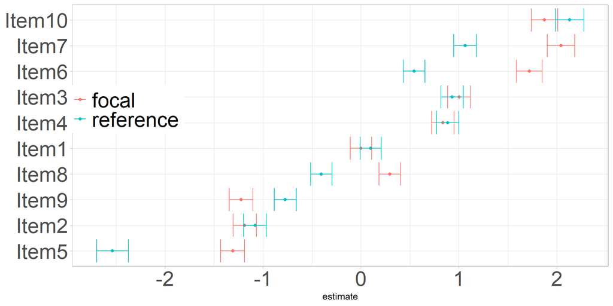

```r
my_items = data.frame(items = rownames(itemFR),
                      focal = itemFR$bF,
                      reference = itemFR$bR)
my_se = data.frame(items = rownames(itemFR),
                      focal = itemFR$se.b.,
                      reference = itemFR$se.b..1)
my_items = pivot_longer(my_items,
             cols = !items,
             names_to = "group",
             values_to = "estimate")

my_se = pivot_longer(my_se,
             cols = !items,
             names_to = "group",
             values_to = "se")

my_items = merge(my_items, my_se)

ggplot(my_items,
       aes(x = estimate, y = reorder(items, estimate),
           color = group)) + geom_point() +
  geom_errorbarh(aes(xmin = estimate -se, xmax = estimate + se)) + theme_light() +
  theme(legend.position = c(.10, .6),
        legend.title = element_blank(),
        legend.text = element_text(size = 24),
        axis.text = element_text(size = 24), axis.title.y = element_blank())
```

## Your turn

Download the data set “difES.csv” from the [shared folder](https://drive.google.com/drive/folders/1EF4cN4yiB3Fft_y2Mh4r0Mclxc6bTRdf?usp=sharing).

Store the downloaded file in the `data` sub folder:

- Import the dataset
- Look at the data!
- Check of the assumptions & Models estimation & Model selection
- Item fit
- DIF investigation with the three methods